# Forecasting Wool Trade

### 6.0.16 M212: SARIMA$(2,1,2)(0,1,2)_{12}$ — ML

```r
make_coef_table(m212_ml, "Coefficients: M212 — SARIMA(2,1,2)(0,1,2)[12], ML")
```

Table 25: Coefficients: M212 — SARIMA(2,1,2)(0,1,2)[12], ML

Coefficients: M212 — SARIMA(2,1,2)(0,1,2)[12], ML

| Coefficient | Estimate | Std.Error | z.value | p.value | Sig |
| --- | --- | --- | --- | --- | --- |
| ar1 | -0.7238 | 0.0935 | -7.7406 | 0.0000 | *** |
| ar2 | 0.1777 | 0.0929 | 1.9137 | 0.0557 |  |
| ma1 | 0.3707 | 0.0793 | 4.6738 | 0.0000 | *** |
| ma2 | -0.5687 | 0.0782 | -7.2702 | 0.0000 | *** |
| sma1 | -0.7606 | 0.0428 | -17.7586 | 0.0000 | *** |
| sma2 | -0.0229 | 0.0424 | -0.5413 | 0.5883 |  |

The ML estimation for SARIMA(2,1,2)(0,1,2)[12] shows a simliar pattern to the CSS result with some improvements.

The ML estimation strengthens the case for AR2 relative to CSS, while sma2 remains insignificant, the core non-seasonal structure (ar1, ma1, ma2) and sesaonal structure (sma1) are highly significant. On Balance, **M212 edges ahead of M111 sufficiently to supersede it as the new benchmark,** but the margin is modest and **M111 remains a credible parsimonious alternative.**

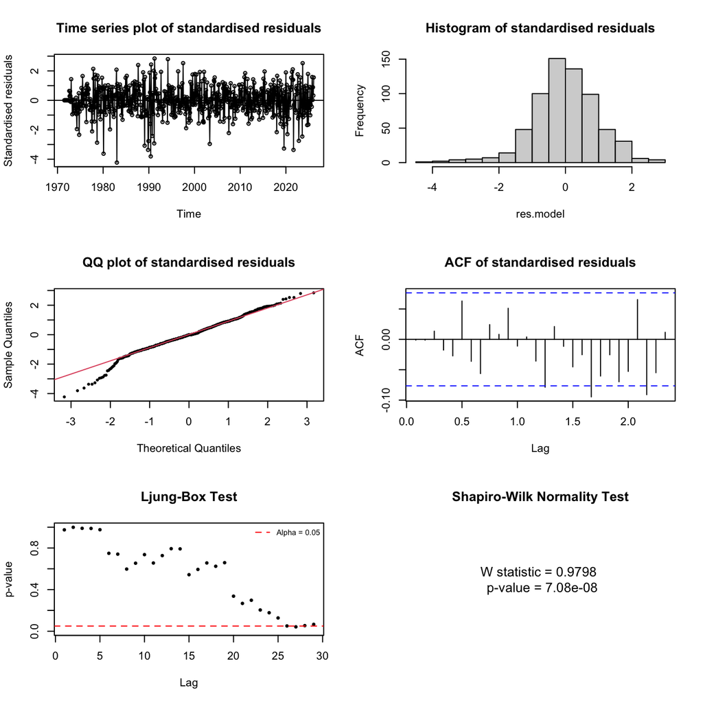

Figure 33: Residual diagnostics: M212 — SARIMA(2,1,2)(0,1,2)[12], ML

```r
residuals_m212_ml <- residual.analysis(m212_ml, std = TRUE, model_class = "ARIMA")
```

- *Time Series Plot*: The standardised residuals fluctuate cleanly around zero with no obvious deterministic trend or remaining seasonal patterns. A few extreme values (exceeding ±3) are visible during historical shock periods (1980s boom and 2020–2022 crisis), which is expected given the volatile nature of the series. Variance clustering is minimal outside these episodes.
- *Histogram*: The distribution is roughly symmetric and well-centered near zero, with a slight left skew and a longer left tail attributable to the isolated historical macro shocks.
- *Q-Q Plot*: The majority of the empirical distribution closely follows the theoretical normal reference line between the −2 and +3 quantiles. The primary deviation remains confined to the lower tail below the −2 theoretical quantile mark, driven directly by the historical outliers. This deviation is not a structural model failure.
- *ACF Plot*: The ACF shows that most bars lie within the 95% confidence bounds. However, some lags fall slightly outside, indicating minor remaining autocorrelation.
- *Ljung-Box Test*: The p-values comfortably clear the alpha baseline at initial lags before entering a steady downward trajectory. This steady decline culminates past lag 26, where the plotted points converge upon or cross beneath the 5% significance boundary ($α=0.05$). This is attributed to the structural break in 1991 rather than model misspecification.
- *Shapiro-Wilk Test*: The test yields W = 0.9798 with p < 0.001, rejecting normality. This rejection is driven by the historical shocks rather than a structural model failure.

Relative to the previous benchmark M111 (SARIMA$(1,1,1)(0,1,2)_{12}$), M212 (SARIMA$(2,1,2)(0,1,2)_{12}$) captures additional short-term dynamics through its second-order AR and MA terms. The borderline significance of the ar2 coefficient (p = 0.0557) is acceptable given the overall improvement in fit and parsimony trade-off. **On balance, M212 edges ahead of M111 to take over as the new benchmark, though the margin is modest and M111 remains a credible parsimonious alternative for sensitivity analysis**.

### 6.0.17 M213: SARIMA$(2,1,3)(0,1,2)_{12}$ — CSS

**Note**

The detailed coefficient interpretations and residual diagnostics for this model are omitted, following the exact estimation, CSS/ML convergence checking, and residual diagnostic framework applied to the benchmark model.

```r
make_coef_table(m213_css, "Coefficients: M213 — SARIMA(2,1,3)(0,1,2)[12], CSS")
```

Table 26: Coefficients: M213 — SARIMA(2,1,3)(0,1,2)[12], CSS

Coefficients: M213 — SARIMA(2,1,3)(0,1,2)[12], CSS

| Coefficient | Estimate | Std.Error | z.value | p.value | Sig |
| --- | --- | --- | --- | --- | --- |
| ar1 | -0.8742 | 0.1456 | -6.0057 | 0.0000 | *** |
| ar2 | 0.0484 | 0.1593 | 0.3040 | 0.7611 |  |
| ma1 | 0.5251 | 0.1502 | 3.4971 | 0.0005 | *** |
| ma2 | -0.4928 | 0.1085 | -4.5424 | 0.0000 | *** |
| ma3 | -0.0615 | 0.0750 | -0.8201 | 0.4122 |  |
| sma1 | -0.7612 | 0.0429 | -17.7600 | 0.0000 | *** |
| sma2 | -0.0230 | 0.0426 | -0.5401 | 0.5891 |  |

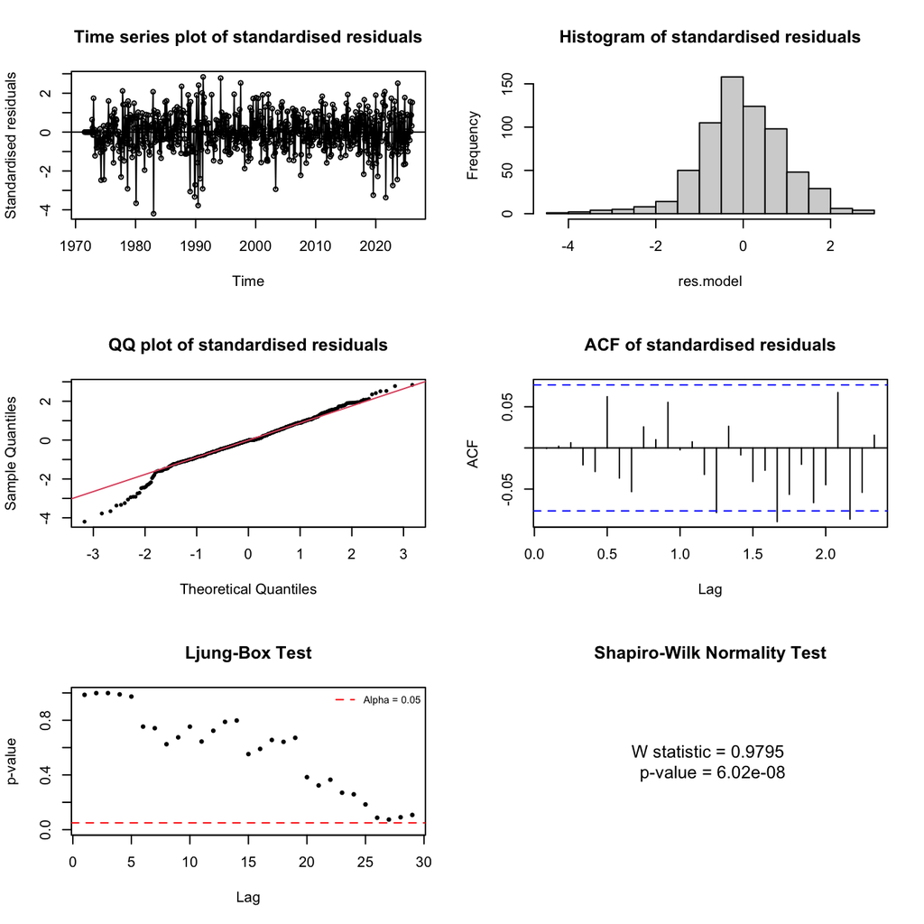

Figure 34: Residual diagnostics: M213 — SARIMA(2,1,3)(0,1,2)[12], CSS

```r
residuals_m213_css <- residual.analysis(m213_css, std = TRUE, model_class = "ARIMA")
```

### 6.0.18 M213: SARIMA$(2,1,3)(0,1,2)_{12}$ — ML

**Note**

The detailed coefficient interpretations and residual diagnostics for this model are omitted, following the exact estimation, CSS/ML convergence checking, and residual diagnostic framework applied to the benchmark model.

```r
make_coef_table(m213_ml, "Coefficients: M213 — SARIMA(2,1,3)(0,1,2)[12], ML")
```

Table 27: Coefficients: M213 — SARIMA(2,1,3)(0,1,2)[12], ML

Coefficients: M213 — SARIMA(2,1,3)(0,1,2)[12], ML

| Coefficient | Estimate | Std.Error | z.value | p.value | Sig |
| --- | --- | --- | --- | --- | --- |
| ar1 | 0.0316 | 0.0542 | 0.5835 | 0.5596 |  |
| ar2 | 0.8318 | 0.0464 | 17.9162 | 0.0000 | *** |
| ma1 | -0.4199 | 0.0652 | -6.4401 | 0.0000 | *** |
| ma2 | -0.9319 | 0.0436 | -21.3585 | 0.0000 | *** |
| ma3 | 0.3641 | 0.0465 | 7.8351 | 0.0000 | *** |
| sma1 | -0.7382 | 0.0426 | -17.3321 | 0.0000 | *** |
| sma2 | -0.0337 | 0.0421 | -0.8023 | 0.4224 |  |

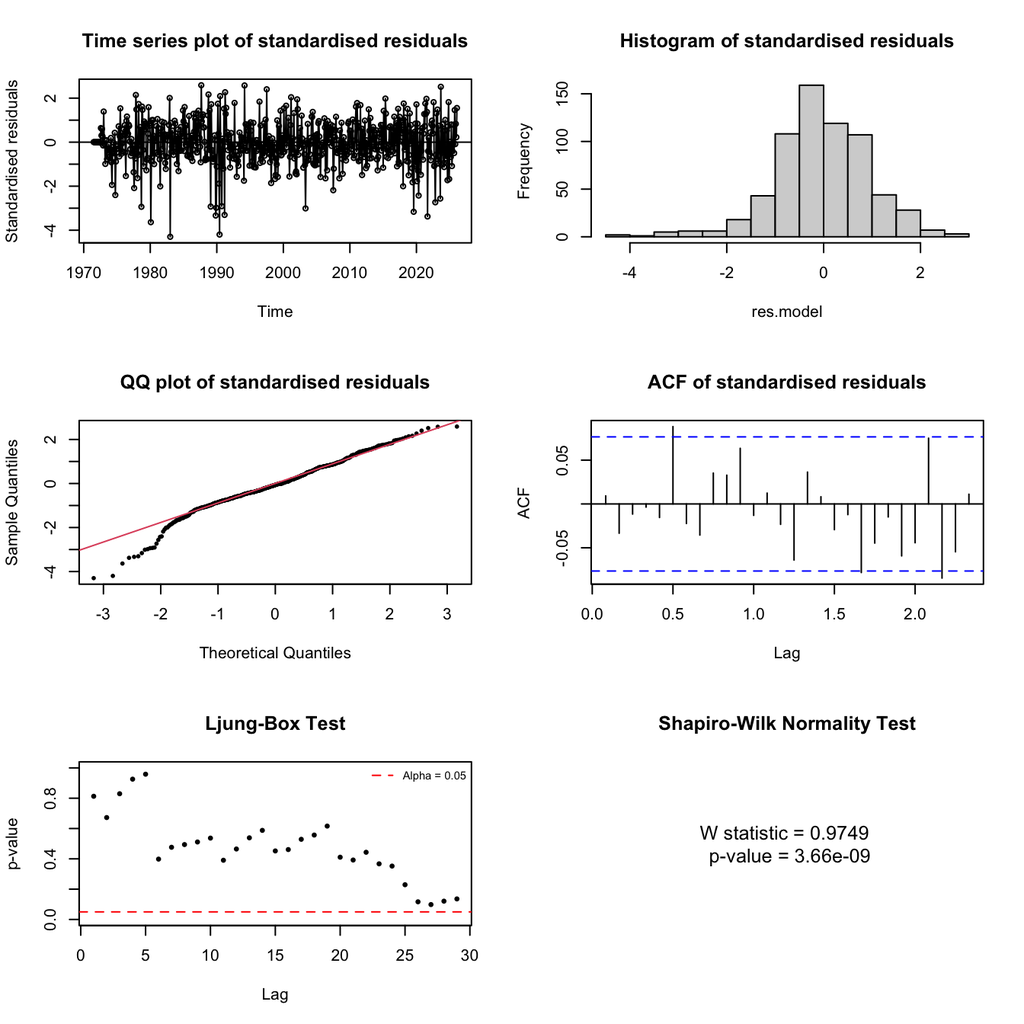

Figure 35: Residual diagnostics: M213 — SARIMA(2,1,3)(0,1,2)[12], ML

```r
residuals_m213_ml <- residual.analysis(m213_ml, std = TRUE, model_class = "ARIMA")
```

### 6.0.19 M213: SARIMA$(2,1,3)(0,1,2)_{12}$ — CSS-ML

**Note**

The detailed coefficient interpretations and residual diagnostics for this model are omitted, following the exact estimation, CSS/ML convergence checking, and residual diagnostic framework applied to the benchmark model.

```r
make_coef_table(m213_cssml, "Coefficients: M213 — SARIMA(2,1,3)(0,1,2)[12], CSS-ML")
```

Table 28: Coefficients: M213 — SARIMA(2,1,3)(0,1,2)[12], CSS-ML

Coefficients: M213 — SARIMA(2,1,3)(0,1,2)[12], CSS-ML

| Coefficient | Estimate | Std.Error | z.value | p.value | Sig |
| --- | --- | --- | --- | --- | --- |
| ar1 | -0.6502 | 0.6549 | -0.9928 | 0.3208 |  |
| ar2 | 0.2419 | 0.5703 | 0.4242 | 0.6715 |  |
| ma1 | 0.2965 | 0.6594 | 0.4496 | 0.6530 |  |
| ma2 | -0.6039 | 0.3162 | -1.9097 | 0.0562 |  |
| ma3 | 0.0328 | 0.2912 | 0.1125 | 0.9104 |  |
| sma1 | -0.7606 | 0.0428 | -17.7584 | 0.0000 | *** |
| sma2 | -0.0234 | 0.0425 | -0.5496 | 0.5826 |  |

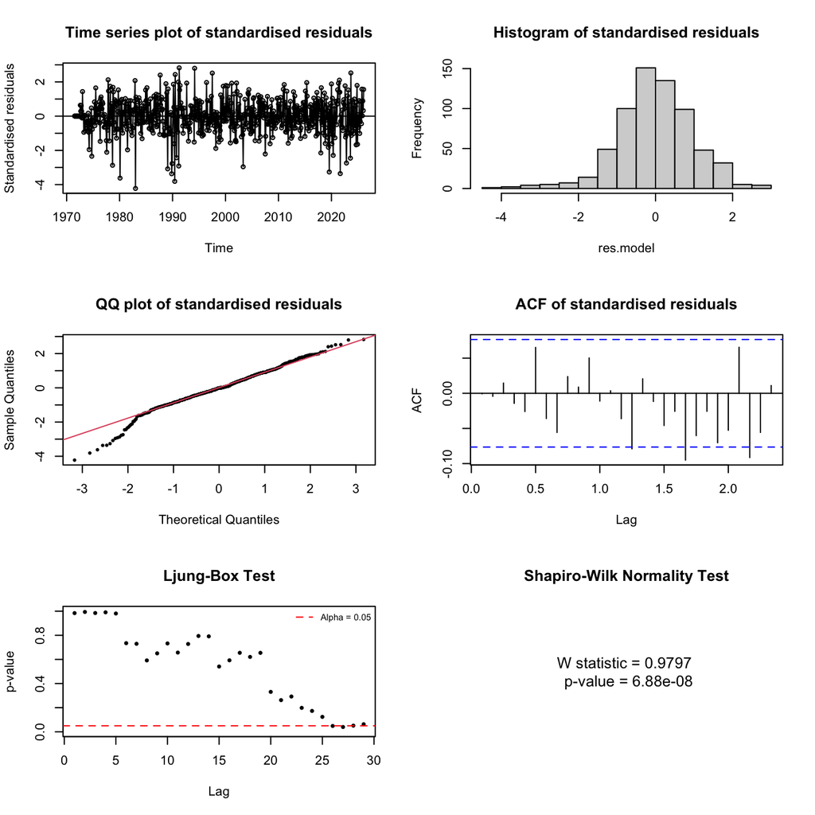

Figure 36: Residual diagnostics: M213 — SARIMA(2,1,3)(0,1,2)[12], CSS-ML

```r
residuals_m213_cssml <- residual.analysis(m213_cssml, std = TRUE, model_class = "ARIMA")
```

### 6.0.20 M311: SARIMA$(3,1,1)(0,1,2)_{12}$ — CSS

```r
make_coef_table(m311_css, "Coefficients: M311 — SARIMA(3,1,1)(0,1,2)[12], CSS")
```

Table 29: Coefficients: M311 — SARIMA(3,1,1)(0,1,2)[12], CSS

Coefficients: M311 — SARIMA(3,1,1)(0,1,2)[12], CSS

| Coefficient | Estimate | Std.Error | z.value | p.value | Sig |
| --- | --- | --- | --- | --- | --- |
| ar1 | 0.2137 | 0.1534 | 1.3927 | 0.1637 |  |
| ar2 | -0.0431 | 0.0655 | -0.6589 | 0.5100 |  |
| ar3 | 0.0354 | 0.0520 | 0.6807 | 0.4960 |  |
| ma1 | -0.5711 | 0.1492 | -3.8286 | 0.0001 | *** |
| sma1 | -0.7737 | 0.0419 | -18.4737 | 0.0000 | *** |
| sma2 | -0.0181 | 0.0419 | -0.4314 | 0.6662 |  |

- *Non-Seasonal AR/MA Terms*: The non-seasonal autoregressive structure is highly insignificant across all specified orders under CSS estimation. The first-order AR term ar1 (0.2137, p=0.1637), second-order AR term ar2 (−0.0431, p=0.5100), and third-order AR term ar3 (0.0354, p=0.4960) all fail to reach statistical significance, indicating that the expanded AR(3) framework adds no meaningful explanatory power. Conversely, the single moving average term ma1 is highly significant (−0.5711, p<0.001), confirming that the short-term non-seasonal dynamics are predominantly moving-average driven.
- *Seasonal MA Terms*: The first-order seasonal moving average term sma1 is highly significant (−0.7737, p<0.001), verifying its essential and stable role in capturing seasonal dependence. The second-order seasonal moving average term sma2 (−0.0181, p=0.6662) remains statistically insignificant, conforming to the structural patterns observed across all previously tested candidate models.

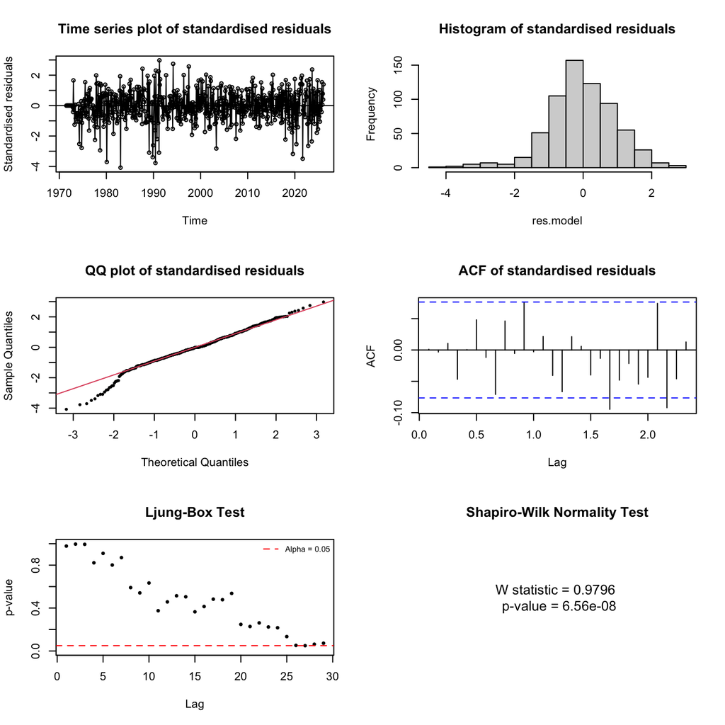

Figure 37: Residual diagnostics: M311 — SARIMA(3,1,1)(0,1,2)[12], CSS

```r
residuals_m311_css <- residual.analysis(m311_css, std = TRUE, model_class = "ARIMA")
```

### 6.0.21 M311: SARIMA$(3,1,1)(0,1,2)_{12}$ — ML

```r
make_coef_table(m311_ml, "Coefficients: M311 — SARIMA(3,1,1)(0,1,2)[12], ML")
```

Table 30: Coefficients: M311 — SARIMA(3,1,1)(0,1,2)[12], ML

Coefficients: M311 — SARIMA(3,1,1)(0,1,2)[12], ML

| Coefficient | Estimate | Std.Error | z.value | p.value | Sig |
| --- | --- | --- | --- | --- | --- |
| ar1 | 0.6100 | 0.0402 | 15.1880 | 0.0000 | *** |
| ar2 | 0.1053 | 0.0459 | 2.2930 | 0.0219 | * |
| ar3 | 0.1627 | 0.0396 | 4.1075 | 0.0000 | *** |
| ma1 | -0.9883 | 0.0089 | -110.8613 | 0.0000 | *** |
| sma1 | -0.7570 | 0.0421 | -17.9976 | 0.0000 | *** |
| sma2 | -0.0197 | 0.0418 | -0.4716 | 0.6372 |  |

- *Non-Seasonal AR/MA Terms*: The non-seasonal structure is highly significant under Maximum Likelihood (ML) estimation, contrasting sharply with its CSS counterpart. The first-order AR term ar1 (0.6100, p<0.001) and the third-order AR term ar3 (0.1627, p<0.001) are highly significant, while the second-order AR term ar2 (0.1053, p=0.0219) achieves significance at the 5% level. Additionally, the single moving average term ma1 is highly significant (−0.9883, p<0.001). This widespread significance across the non-seasonal parameters provides strong statistical justification for the expanded AR(3) baseline under this specific optimization method.
- *Seasonal MA Terms*: The first-order seasonal moving average term sma1 is highly significant (−0.7570, p<0.001), reaffirming its critical and stable role in accounting for seasonal dependency. Conversely, the second-order seasonal moving average term sma2 (−0.0197, p=0.6372) remains statistically insignificant, matching the established pattern observed uniformly across all prior model variants.

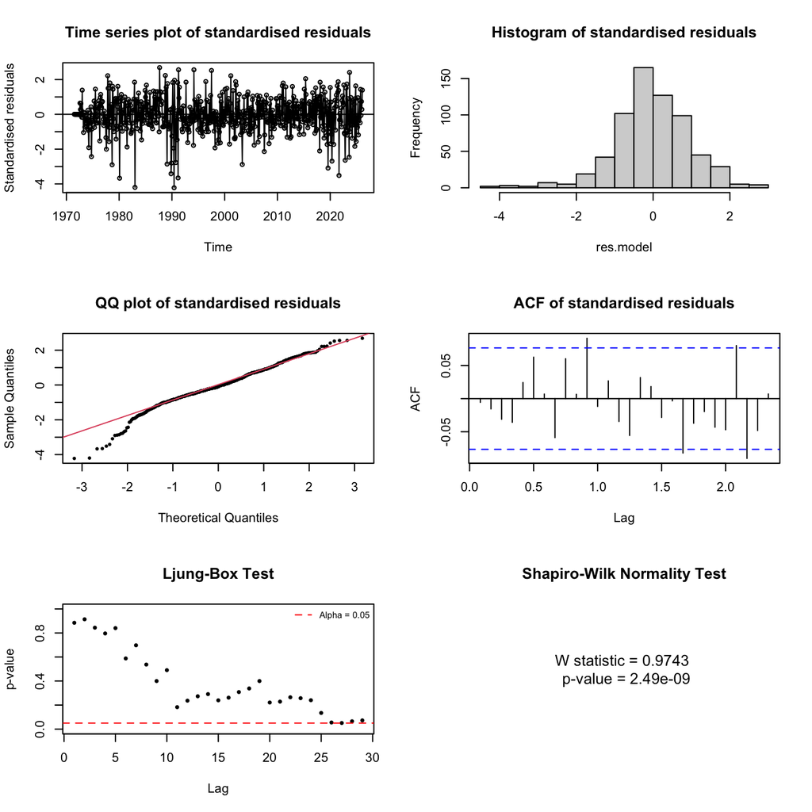

Figure 38: Residual diagnostics: M311 — SARIMA(3,1,1)(0,1,2)[12], ML

```r
residuals_m311_ml <- residual.analysis(m311_ml, std = TRUE, model_class = "ARIMA")
```

- *Time Series Plot*: The standardised residuals fluctuate cleanly around zero, indicating a stable mean with no obvious deterministic trend or uncaptured seasonal patterns remaining. A few extreme spikes exceeding ±3 are visible during known historical shock periods. Outside these specific intervals, variance clustering is minimal, suggesting a stable conditional variance.
- *Histogram*: The residual distribution is centered near zero and appears broadly symmetric about its median. However, it displays a pronounced negative skewness characterized by an elongated left tail, which is directly attributable to severe, isolated historical macro shocks.
- *Q-Q Plot*: The majority of the empirical distribution closely tracks the theoretical normal reference line between the −2 and +3 quantiles. The primary deviation is strictly confined to the lower tail below the −2 theoretical quantile mark.
- *ACF Plot*: The ACF shows that most bars lie safely within the 95% confidence bounds. However, a few specific bars marginally puncture the blue dashed threshold line, indicating that minor residual autocorrelation remains uncaptured despite the structural optimization of the non-seasonal components.
- *Ljung-Box Test*: The test yields p-values that start well above the alpha threshold at early lags, but exhibit a steady downward trajectory as the lag order increases. By lag 25, the p-values hover critically close to the red dashed significance threshold ($α=0.05$), ultimately falling below this line after lag 26.
- *Shapiro-Wilk Test*: W = 0.9743, p < 0.001, statistically rejecting the null hypothesis of normality at any conventional significance level. This rejection is overwhelmingly driven by the extreme tail behavior from historical shocks rather than a fundamental flaw in the structural modeling.

**The CSS-ML estimation will determine whether this near-invertibility issue persists or if M311 is disqualified due to instability.**

### 6.0.22 M311: SARIMA$(3,1,1)(0,1,2)_{12}$ — CSS-ML

```r
make_coef_table(m311_cssml, "Coefficients: M311 — SARIMA(3,1,1)(0,1,2)[12], CSS-ML")
```

Table 31: Coefficients: M311 — SARIMA(3,1,1)(0,1,2)[12], CSS-ML

Coefficients: M311 — SARIMA(3,1,1)(0,1,2)[12], CSS-ML

| Coefficient | Estimate | Std.Error | z.value | p.value | Sig |
| --- | --- | --- | --- | --- | --- |
| ar1 | 0.6101 | 0.0402 | 15.1881 | 0.0000 | *** |
| ar2 | 0.1053 | 0.0459 | 2.2933 | 0.0218 | * |
| ar3 | 0.1627 | 0.0396 | 4.1074 | 0.0000 | *** |
| ma1 | -0.9883 | 0.0089 | -110.7901 | 0.0000 | *** |
| sma1 | -0.7569 | 0.0421 | -17.9960 | 0.0000 | *** |
| sma2 | -0.0198 | 0.0418 | -0.4737 | 0.6357 |  |

- *Non-Seasonal AR/MA Terms*: The non-seasonal parameters are highly significant under the combined CSS-ML optimization framework, showing strong convergence with the pure ML results. The first-order AR term ar1 (0.6101, p<0.001) and third-order AR term ar3 (0.1627, p<0.001) are highly significant, while the second-order AR term ar2 (0.1053, p=0.0218) is significant at the conventional 5% level. The single moving average term ma1 is also highly significant (−0.9883, p<0.001). This broad significance across the non-seasonal terms provides robust mathematical backing for the expanded AR(3) framework under this estimation method.
- *Seasonal MA Terms*: The first-order seasonal moving average term sma1 is highly significant (−0.7569, p<0.001), confirming its critical, unyielding role in capturing seasonal dependencies across all models. Conversely, the second-order seasonal moving average term sma2 (−0.0198, p=0.6357) remains statistically insignificant, conforming precisely to the structural patterns observed uniformly throughout this analysis.

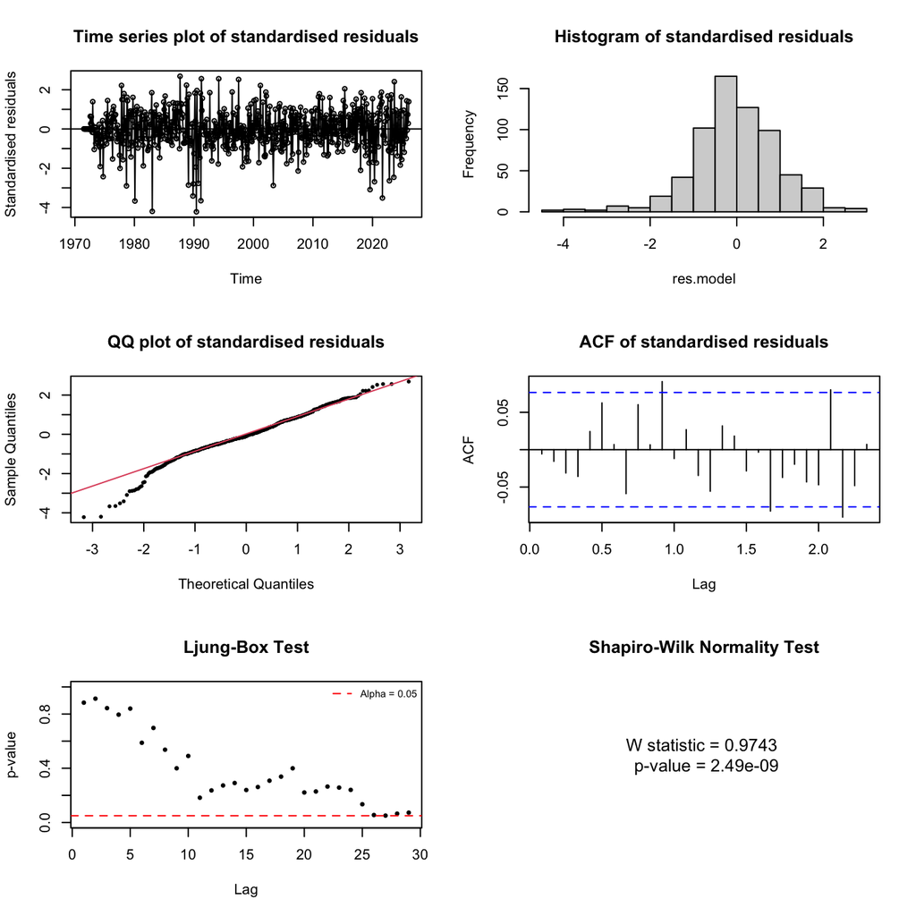

Figure 39: Residual diagnostics: M311 — SARIMA(3,1,1)(0,1,2)[12], CSS-ML

```r
residuals_m311_cssml <- residual.analysis(m311_cssml, std = TRUE, model_class = "ARIMA")
```

**Figure 39. Residuals M311 CSS-ML**

**Model Evaluation Summary.** The CSS-ML and ML estimations converge on identical solutions, confirming that the CSS numerical instability was an isolated estimation artefact rather than a fundamental model failure. Under both ML and CSS-ML, all non-seasonal parameters achieve significance, presenting a stronger and more complete coefficient profile than the current benchmark M212, where ar2 remains borderline across all estimation methods. The near-unit ma1 (|ma1| = 0.9883) is acknowledged as a proximity concern to the invertibility boundary and warrants monitoring, but does not constitute a technical violation. Residual diagnostics are broadly comparable to M212.

**On balance, M311 presents a competitive coefficient profile relative to M212 and competing candidate, with the information criteria and in-sample accuracy comparison in the following section providing the final basis for model selection**.

### 6.0.23 M312: SARIMA$(3,1,2)(0,1,2)_{12}$ — CSS

**Note**

The detailed coefficient interpretations and residual diagnostics for this model are omitted, following the exact estimation, CSS/ML convergence checking, and residual diagnostic framework applied to the benchmark model.

```r
make_coef_table(m312_css, "Coefficients: M312 — SARIMA(3,1,2)(0,1,2)[12], CSS")
```

Table 32: Coefficients: M312 — SARIMA(3,1,2)(0,1,2)[12], CSS

Coefficients: M312 — SARIMA(3,1,2)(0,1,2)[12], CSS

| Coefficient | Estimate | Std.Error | z.value | p.value | Sig |
| --- | --- | --- | --- | --- | --- |
| ar1 | -0.2341 | 0.4355 | -0.5377 | 0.5908 |  |
| ar2 | 0.0865 | 0.1476 | 0.5858 | 0.5580 |  |
| ar3 | 0.0414 | 0.0628 | 0.6595 | 0.5096 |  |
| ma1 | -0.1214 | 0.4349 | -0.2792 | 0.7801 |  |
| ma2 | -0.2942 | 0.2536 | -1.1603 | 0.2459 |  |
| sma1 | -0.7761 | 0.0420 | -18.4630 | 0.0000 | *** |
| sma2 | -0.0163 | 0.0420 | -0.3885 | 0.6977 |  |

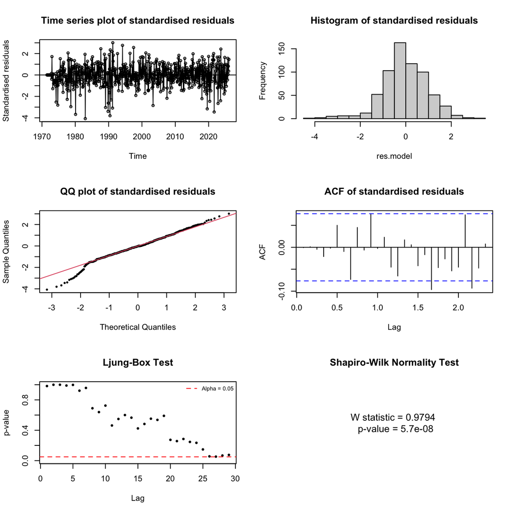

Figure 40: Residual diagnostics: M312 — SARIMA(3,1,2)(0,1,2)[12], CSS

```r
residuals_m312_css <- residual.analysis(m312_css, std = TRUE, model_class = "ARIMA")
```

### 6.0.24 M312: SARIMA$(3,1,2)(0,1,2)_{12}$ — ML

**Note**

The detailed coefficient interpretations and residual diagnostics for this model are omitted, following the exact estimation, CSS/ML convergence checking, and residual diagnostic framework applied to the benchmark model.

```r
make_coef_table(m312_ml, "Coefficients: M312 — SARIMA(3,1,2)(0,1,2)[12], ML")
```

Table 33: Coefficients: M312 — SARIMA(3,1,2)(0,1,2)[12], ML

Coefficients: M312 — SARIMA(3,1,2)(0,1,2)[12], ML

| Coefficient | Estimate | Std.Error | z.value | p.value | Sig |
| --- | --- | --- | --- | --- | --- |
| ar1 | -0.1362 | 0.7318 | -0.1862 | 0.8523 |  |
| ar2 | 0.1361 | 0.1710 | 0.7959 | 0.4261 |  |
| ar3 | 0.0698 | 0.0917 | 0.7611 | 0.4466 |  |
| ma1 | -0.2246 | 0.7324 | -0.3066 | 0.7591 |  |
| ma2 | -0.3111 | 0.3782 | -0.8225 | 0.4108 |  |
| sma1 | -0.7790 | 0.0423 | -18.3967 | 0.0000 | *** |
| sma2 | -0.0110 | 0.0421 | -0.2610 | 0.7941 |  |

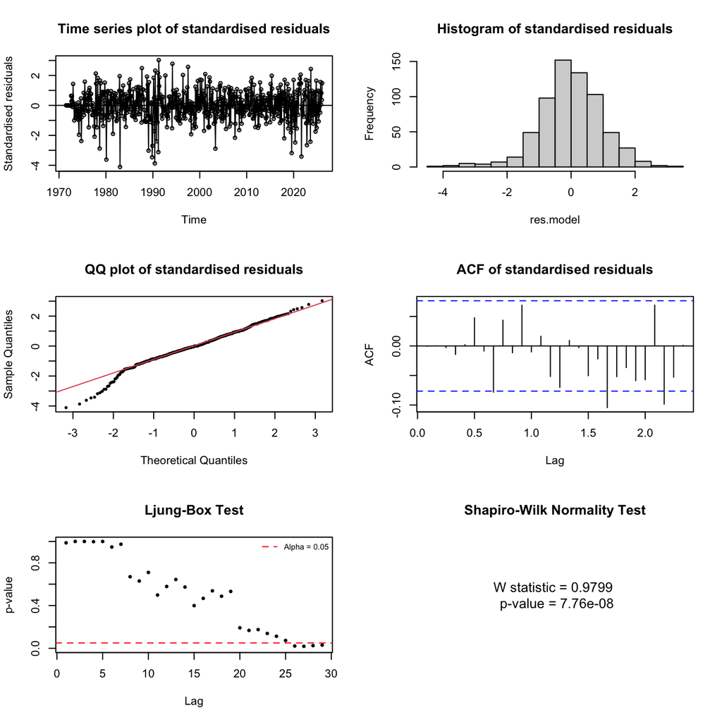

Figure 41: Residual diagnostics: M312 — SARIMA(3,1,2)(0,1,2)[12], ML

```r
residuals_m312_ml <- residual.analysis(m312_ml, std = TRUE, model_class = "ARIMA")
```

### 6.0.25 M313: SARIMA$(3,1,3)(0,1,2)_{12}$ — CSS

**Note**

The detailed coefficient interpretations and residual diagnostics for this model are omitted, following the exact estimation, CSS/ML convergence checking, and residual diagnostic framework applied to the benchmark model.

```r
make_coef_table(m313_css, "Coefficients: M313 — SARIMA(3,1,3)(0,1,2)[12], CSS")
```

Table 34: Coefficients: M313 — SARIMA(3,1,3)(0,1,2)[12], CSS

Coefficients: M313 — SARIMA(3,1,3)(0,1,2)[12], CSS

| Coefficient | Estimate | Std.Error | z.value | p.value | Sig |
| --- | --- | --- | --- | --- | --- |
| ar1 | -0.6220 | NaN | NaN | NaN | NA |
| ar2 | -0.3646 | 0.0845 | -4.3133 | 0.0000 | *** |
| ar3 | 0.1913 | 0.0872 | 2.1940 | 0.0282 | * |
| ma1 | 0.2690 | NaN | NaN | NaN | NA |
| ma2 | 0.0192 | 0.1447 | 0.1324 | 0.8947 |  |
| ma3 | -0.3544 | NaN | NaN | NaN | NA |
| sma1 | -0.7802 | 0.0423 | -18.4434 | 0.0000 | *** |
| sma2 | -0.0100 | 0.0422 | -0.2364 | 0.8131 |  |

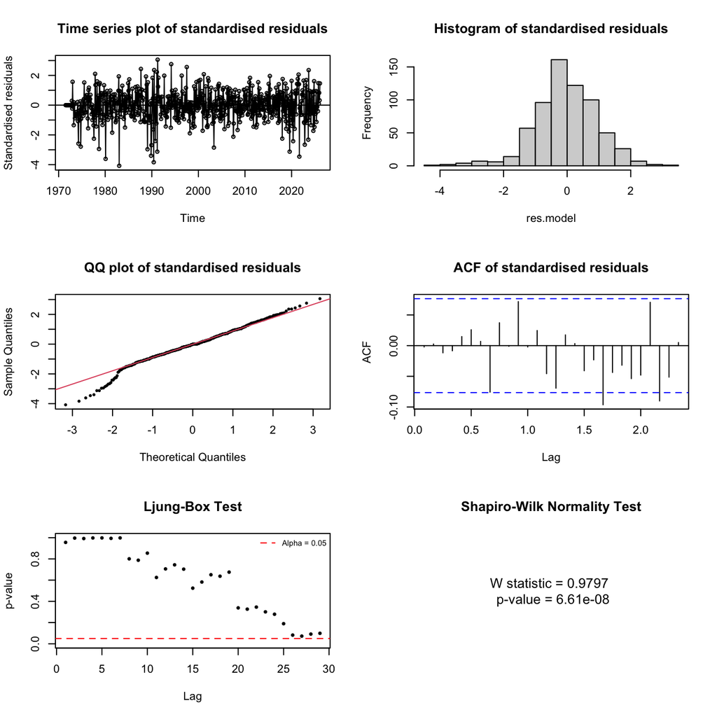

Figure 42: Residual diagnostics: M313 — SARIMA(3,1,3)(0,1,2)[12], CSS

```r
residuals_m313_css <- residual.analysis(m313_css, std = TRUE, model_class = "ARIMA")
```

### 6.0.26 M313: SARIMA$(3,1,3)(0,1,2)_{12}$ — ML

**Note**

The detailed coefficient interpretations and residual diagnostics for this model are omitted, following the exact estimation, CSS/ML convergence checking, and residual diagnostic framework applied to the benchmark model.

```r
make_coef_table(m313_ml, "Coefficients: M313 — SARIMA(3,1,3)(0,1,2)[12], ML")
```

Table 35: Coefficients: M313 — SARIMA(3,1,3)(0,1,2)[12], ML

Coefficients: M313 — SARIMA(3,1,3)(0,1,2)[12], ML

| Coefficient | Estimate | Std.Error | z.value | p.value | Sig |
| --- | --- | --- | --- | --- | --- |
| ar1 | -0.4413 | 0.1557 | -2.8349 | 0.0046 | ** |
| ar2 | -0.6252 | 0.1314 | -4.7564 | 0.0000 | *** |
| ar3 | 0.3032 | 0.0923 | 3.2843 | 0.0010 | ** |
| ma1 | 0.0804 | 0.1500 | 0.5364 | 0.5917 |  |
| ma2 | 0.3591 | 0.1335 | 2.6909 | 0.0071 | ** |
| ma3 | -0.5578 | 0.0928 | -6.0085 | 0.0000 | *** |
| sma1 | -0.8045 | 0.0445 | -18.0611 | 0.0000 | *** |
| sma2 | 0.0163 | 0.0441 | 0.3702 | 0.7112 |  |

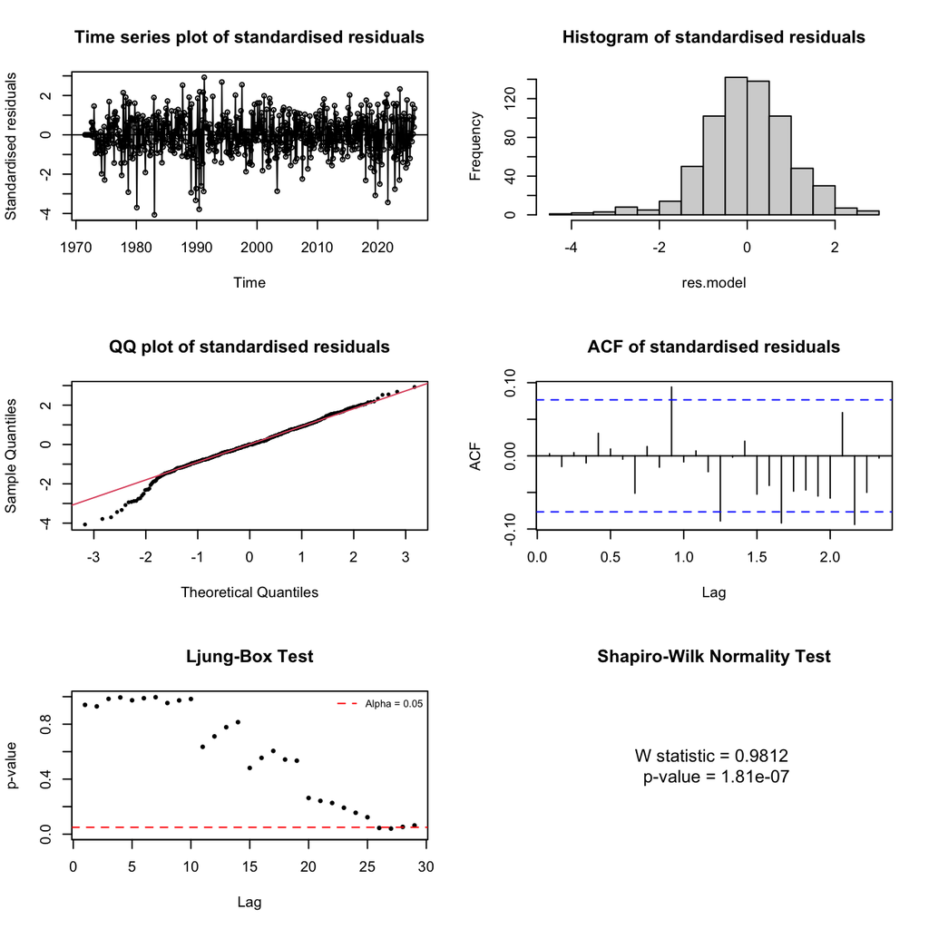

Figure 43: Residual diagnostics: M313 — SARIMA(3,1,3)(0,1,2)[12], ML

```r
residuals_m313_ml <- residual.analysis(m313_ml, std = TRUE, model_class = "ARIMA")
```

### 6.0.27 M313: SARIMA$(3,1,3)(0,1,2)_{12}$ — CSS-ML

**Note**

The detailed coefficient interpretations and residual diagnostics for this model are omitted, following the exact estimation, CSS/ML convergence checking, and residual diagnostic framework applied to the benchmark model.

```r
make_coef_table(m313_cssml, "Coefficients: M313 — SARIMA(3,1,3)(0,1,2)[12], CSS-ML")
```

Table 36: Coefficients: M313 — SARIMA(3,1,3)(0,1,2)[12], CSS-ML

Coefficients: M313 — SARIMA(3,1,3)(0,1,2)[12], CSS-ML

| Coefficient | Estimate | Std.Error | z.value | p.value | Sig |
| --- | --- | --- | --- | --- | --- |
| ar1 | -0.4413 | 0.1557 | -2.8349 | 0.0046 | ** |
| ar2 | -0.6252 | 0.1314 | -4.7564 | 0.0000 | *** |
| ar3 | 0.3032 | 0.0923 | 3.2843 | 0.0010 | ** |
| ma1 | 0.0804 | 0.1500 | 0.5364 | 0.5917 |  |
| ma2 | 0.3591 | 0.1335 | 2.6909 | 0.0071 | ** |
| ma3 | -0.5578 | 0.0928 | -6.0085 | 0.0000 | *** |
| sma1 | -0.8045 | 0.0445 | -18.0611 | 0.0000 | *** |
| sma2 | 0.0163 | 0.0441 | 0.3702 | 0.7112 |  |

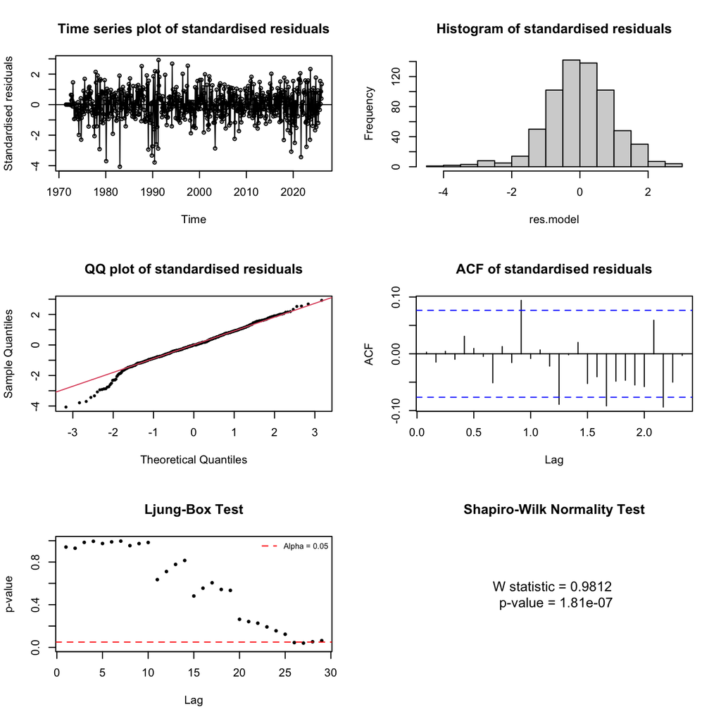

Figure 44: Residual diagnostics: M313 — SARIMA(3,1,3)(0,1,2)[12], CSS-ML

```r
residuals_m313_cssml <- residual.analysis(m313_cssml, std = TRUE, model_class = "ARIMA")
```

### 6.0.28 Synthesis: Parameter Estimation and Residual Diagnostics

After evaluating all eleven candidate models across coefficient stability, estimation method consistency, and residual diagnostics, the viable candidates are ranked as follows:

- **1st — M311: SARIMA**$(3,1,1)(0,1,2)_{12}$: The strongest coefficient profile in the candidate set under ML and CSS-ML, with all non-seasonal parameters achieving significance — ar1 (0.6101, p<0.001), ar2 (0.1053, p=0.022), ar3 (0.1627, p<0.001), and ma1 (−0.9883, p<0.001). ML and CSS-ML converge on identical solutions, confirming that the CSS instability was an isolated estimation artefact. Residual diagnostics are broadly adequate and comparable to M212. The near-unit ma1 (|ma1| = 0.9883) is acknowledged as a proximity concern to the invertibility boundary but does not constitute a technical violation. M311 is carried forward as the primary candidate.
- **2nd — M212: SARIMA**$(2,1,2)(0,1,2)_{12}$: A stable and well-behaved model across all estimation methods with no sign reversals or near-cancellation. The borderline ar2 (p ≈ 0.056–0.080) is the sole acknowledged weakness. Residuals are adequate with a Ljung-Box trajectory holding above 0.05 through approximately lags 20–26. M212 is retained as the parsimonious runner-up with moderate, well-behaved coefficients throughout.
- **3rd — M111: SARIMA**$(1,1,1)(0,1,2)_{12}$: The most parsimonious viable model. All non-seasonal parameters are robustly significant and stable across CSS and ML with no identification concerns. Residual diagnostics are comparable to M212 at a lower parameter cost.

Based on parameter behavior and residual diagnostics, the most structurally sound models have been identified. **The next stage will leverage AIC/BIC and in-sample accuracy to formally confirm the final selection**.

# 7 Model Selection

## 7.1 Information Criteria Comparison

```r
models_ml <- list(m012_ml, m013_ml, m111_ml, m112_ml, m113_ml,
                  m211_ml, m212_ml, m213_ml, m311_ml, m312_ml, m313_ml)

labels_ml <- c(
  "M012: SARIMA(0,1,2)(0,1,2)[12]",
  "M013: SARIMA(0,1,3)(0,1,2)[12]",
  "M111: SARIMA(1,1,1)(0,1,2)[12]",
  "M112: SARIMA(1,1,2)(0,1,2)[12]",
  "M113: SARIMA(1,1,3)(0,1,2)[12]",
  "M211: SARIMA(2,1,1)(0,1,2)[12]",
  "M212: SARIMA(2,1,2)(0,1,2)[12]",
  "M213: SARIMA(2,1,3)(0,1,2)[12]",
  "M311: SARIMA(3,1,1)(0,1,2)[12]",
  "M312: SARIMA(3,1,2)(0,1,2)[12]",
  "M313: SARIMA(3,1,3)(0,1,2)[12]"
)

ic_raw <- data.frame(
  Model = labels_ml,
  df    = sapply(models_ml, function(m) length(m$coef) + 1L),
  AIC   = round(sapply(models_ml, AIC), 3)
)

aic_sorted <- sort.score(ic_raw, score = "aic")
knitr::kable(aic_sorted, align = "lccc", row.names = FALSE, booktabs = TRUE)
```

Table 37: Candidate models ranked by AIC (ML method; lower = better).

| Model | df | AIC |
| --- | --- | --- |
| M213: SARIMA(2,1,3)(0,1,2)[12] | 8 | 1851.945 |
| M311: SARIMA(3,1,1)(0,1,2)[12] | 7 | 1855.107 |
| M212: SARIMA(2,1,2)(0,1,2)[12] | 7 | 1859.726 |
| M113: SARIMA(1,1,3)(0,1,2)[12] | 7 | 1859.842 |
| M012: SARIMA(0,1,2)(0,1,2)[12] | 5 | 1861.427 |
| M111: SARIMA(1,1,1)(0,1,2)[12] | 5 | 1862.370 |
| M112: SARIMA(1,1,2)(0,1,2)[12] | 6 | 1862.701 |
| M013: SARIMA(0,1,3)(0,1,2)[12] | 6 | 1863.160 |
| M211: SARIMA(2,1,1)(0,1,2)[12] | 6 | 1863.855 |
| M313: SARIMA(3,1,3)(0,1,2)[12] | 9 | 1864.188 |
| M312: SARIMA(3,1,2)(0,1,2)[12] | 8 | 1865.638 |

**AIC ranking** (Table 37). AIC tends to favour more flexible specifications. The top-ranked model by AIC is M213 (1851.9), which is disqualified due to the most severe parameter instability in the candidate set, three estimation methods producing three structurally incompatible solutions.

Removing M213 from contention, M311 ranks first on AIC among all viable candidates (1855.1), outperforming M212 by 4.6 units (1859.7) with identical degrees of freedom (df = 7). This gap reflects a genuine improvement in fit rather than a parsimony trade-off. The near-unit ma1 (|ma1| = 0.9883) in M311 is acknowledged as a proximity concern but does not constitute a technical disqualification, as the model remains invertible.

M113 sits at 1859.842, effectively tied with M212 (difference of 0.116 units), but M113’s CSS/ML structural reversal identified in the synthesis prevents it from being elevated on this basis alone. Among the remaining candidates, M212 (1859.7), M012 (1861.4), and M111 (1862.4) follow in order.

```r
ic_raw_bic <- data.frame(
  Model = labels_ml,
  df    = sapply(models_ml, function(m) length(m$coef) + 1L),
  BIC   = round(sapply(models_ml, BIC), 3)
)

bic_sorted <- sort.score(ic_raw_bic, score = "bic")
knitr::kable(bic_sorted, align = "lccc", row.names = FALSE, booktabs = TRUE)
```

Table 38: Candidate models ranked by BIC (ML method; lower = better).

| Model | df | BIC |
| --- | --- | --- |
| M012: SARIMA(0,1,2)(0,1,2)[12] | 5 | 1883.757 |
| M111: SARIMA(1,1,1)(0,1,2)[12] | 5 | 1884.701 |
| M311: SARIMA(3,1,1)(0,1,2)[12] | 7 | 1886.370 |
| M213: SARIMA(2,1,3)(0,1,2)[12] | 8 | 1887.674 |
| M112: SARIMA(1,1,2)(0,1,2)[12] | 6 | 1889.498 |
| M013: SARIMA(0,1,3)(0,1,2)[12] | 6 | 1889.956 |
| M211: SARIMA(2,1,1)(0,1,2)[12] | 6 | 1890.652 |
| M212: SARIMA(2,1,2)(0,1,2)[12] | 7 | 1890.989 |
| M113: SARIMA(1,1,3)(0,1,2)[12] | 7 | 1891.105 |
| M312: SARIMA(3,1,2)(0,1,2)[12] | 8 | 1901.367 |
| M313: SARIMA(3,1,3)(0,1,2)[12] | 9 | 1904.383 |

**BIC ranking** (Table 38). The BIC table introduces a parsimony correction that reshapes the ranking. M012 (1883.8) and M111 (1884.7) lead overall, both benefiting from their low parameter counts (df = 5). However, M012 carries no autoregressive component and M111 only a single AR term, both of which were shown insufficient to capture the short-run momentum visible in the Model 3 residual PACF. M311 ranks third overall on BIC (1886.4), ahead of M213 (1887.7), M112 (1889.5), M211 (1890.7), and M212 (1891.0). Among viable candidates with a comparable non-seasonal structure, M311 leads BIC by 4.6 units over M212 reinforcing a consistent fit advantage across both criteria.

### 7.1.1 Synthesis: Information Criteria Comparison

Across both information criteria, the evidence consistently favours M311 among viable candidates with a sufficiently rich non-seasonal structure. M213 is disqualified on structural grounds despite its nominal AIC lead. M012 and M111 lead BIC through parsimony alone but lack the autoregressive depth required to adequately capture short-run dynamics. M311 therefore emerges as the primary finalist on both AIC and BIC among structurally adequate models, with M212 retained as the parsimonious runner-up and M111 as the strictest-parsimony alternative.

Information criteria provide a theoretical comparison. The next section examines in-sample accuracy (RMSE, MAE, MAPE, MASE) to further confirm the selection of M311.

## 7.2 In-Sample Accuracy

```r
acc_list <- lapply(models_ml, function(m) accuracy(m)[1, 1:6])
acc_df   <- as.data.frame(do.call(rbind, acc_list))
colnames(acc_df) <- c("ME", "RMSE", "MAE", "MPE", "MAPE", "MASE")
rownames(acc_df) <- labels_ml

knitr::kable(round(acc_df, 3), booktabs = TRUE, align = "c")
```

Table 39: In-sample accuracy for all candidate models (ML).

|  | ME | RMSE | MAE | MPE | MAPE | MASE |
| --- | --- | --- | --- | --- | --- | --- |
| M012: SARIMA(0,1,2)(0,1,2)[12] | -0.001 | 39.225 | 28.555 | -1.747 | 12.382 | 0.518 |
| M013: SARIMA(0,1,3)(0,1,2)[12] | -0.002 | 39.215 | 28.512 | -1.732 | 12.362 | 0.517 |
| M111: SARIMA(1,1,1)(0,1,2)[12] | -0.003 | 39.243 | 28.630 | -1.763 | 12.421 | 0.520 |
| M112: SARIMA(1,1,2)(0,1,2)[12] | -0.005 | 39.171 | 28.466 | -1.721 | 12.345 | 0.517 |
| M113: SARIMA(1,1,3)(0,1,2)[12] | -0.014 | 38.990 | 28.417 | -1.710 | 12.318 | 0.516 |
| M211: SARIMA(2,1,1)(0,1,2)[12] | 0.001 | 39.244 | 28.570 | -1.740 | 12.387 | 0.519 |
| M212: SARIMA(2,1,2)(0,1,2)[12] | -0.016 | 38.977 | 28.439 | -1.722 | 12.333 | 0.516 |
| M213: SARIMA(2,1,3)(0,1,2)[12] | -0.869 | 38.691 | 28.153 | -2.292 | 12.299 | 0.511 |
| M311: SARIMA(3,1,1)(0,1,2)[12] | -0.790 | 38.923 | 28.160 | -2.281 | 12.300 | 0.511 |
| M312: SARIMA(3,1,2)(0,1,2)[12] | -0.013 | 39.101 | 28.458 | -1.764 | 12.358 | 0.517 |
| M313: SARIMA(3,1,3)(0,1,2)[12] | -0.012 | 38.978 | 28.504 | -1.763 | 12.383 | 0.517 |

RMSE, MAE, MAPE, and MASE are the primary basis for comparing in-sample fit, as they measure forecast error magnitude without the directional cancellation that affects ME and MPE. M213 is excluded from this comparison on the grounds of severe parameter instability established in the estimation section.

M311 carries a ME of −0.790, which is larger in absolute terms than most other candidates. This mild systematic negative bias is acknowledged, but does not outweigh the consistent accuracy advantages M311 demonstrates across the primary absolute error metrics.

Among all favorable candidates, M311 leads on:

- **RMSE**: M311 (38.923) outperforms M212 (38.977) and M111 (39.243)
- **MAE**: M311 (28.160) outperforms M212 (28.439) and M111 (28.630)
- **MAPE**: M311 (12.300) outperforms M212 (12.333) and M111 (12.421)
- **MASE**: M311 (0.511) outperforms M212 (0.516) and M111 (0.520)

However, the relative rankings are highly consistent. M212 places second on every metric, confirming its status as a robust, parsimonious runner-up. Conversely, M111 finishes last across all four metrics, proving that its strict parsimony incurs a clear, albeit modest, accuracy cost.

The accuracy filter therefore corroborates the information criteria ranking. **M311 is confirmed as the finalist model**, leading on AIC, BIC among structurally adequate candidates, and all four primary in-sample accuracy metrics.

## 7.3 Finalist Model

Three sequential filters have been applied — parameter estimation stability and residual diagnostics, information criteria (AIC and BIC), and in-sample accuracy metrics — and all three consistently point to the same conclusion. **SARIMA**$(3,1,1)(0,1,2)_{12}$ (M311) is selected as the final model.

Across all three filters, M311 is the only viable candidate that leads consistently without a disqualifying failure on any dimension. Under ML and CSS-ML, it presents the strongest coefficient profile in the candidate set with all non-seasonal parameters achieving significance. It ranks first on AIC (1855.1) and first on BIC (1886.4) among structurally adequate candidates with comparable non-seasonal complexity.

It (M311) leads on every primary in-sample accuracy metric — RMSE (38.923), MAE (28.160), MAPE (12.300), and MASE (0.511). The near-unit ma1 (|ma1| = 0.9883) is the sole acknowledged concern: it sits in proximity to the invertibility boundary but does not cross it, and is outweighed by the model’s consistent superiority across all three evaluation filters.

```r
make_coef_table(m311_ml, "Coefficients: M311 — SARIMA(3,1,1)(0,1,2)[12], ML")
```

Table 40: Coefficients: M311 — SARIMA(3,1,1)(0,1,2)[12], ML — Final Selected Model

Coefficients: M311 — SARIMA(3,1,1)(0,1,2)[12], ML

| Coefficient | Estimate | Std.Error | z.value | p.value | Sig |
| --- | --- | --- | --- | --- | --- |
| ar1 | 0.6100 | 0.0402 | 15.1880 | 0.0000 | *** |
| ar2 | 0.1053 | 0.0459 | 2.2930 | 0.0219 | * |
| ar3 | 0.1627 | 0.0396 | 4.1075 | 0.0000 | *** |
| ma1 | -0.9883 | 0.0089 | -110.8613 | 0.0000 | *** |
| sma1 | -0.7570 | 0.0421 | -17.9976 | 0.0000 | *** |
| sma2 | -0.0197 | 0.0418 | -0.4716 | 0.6372 |  |

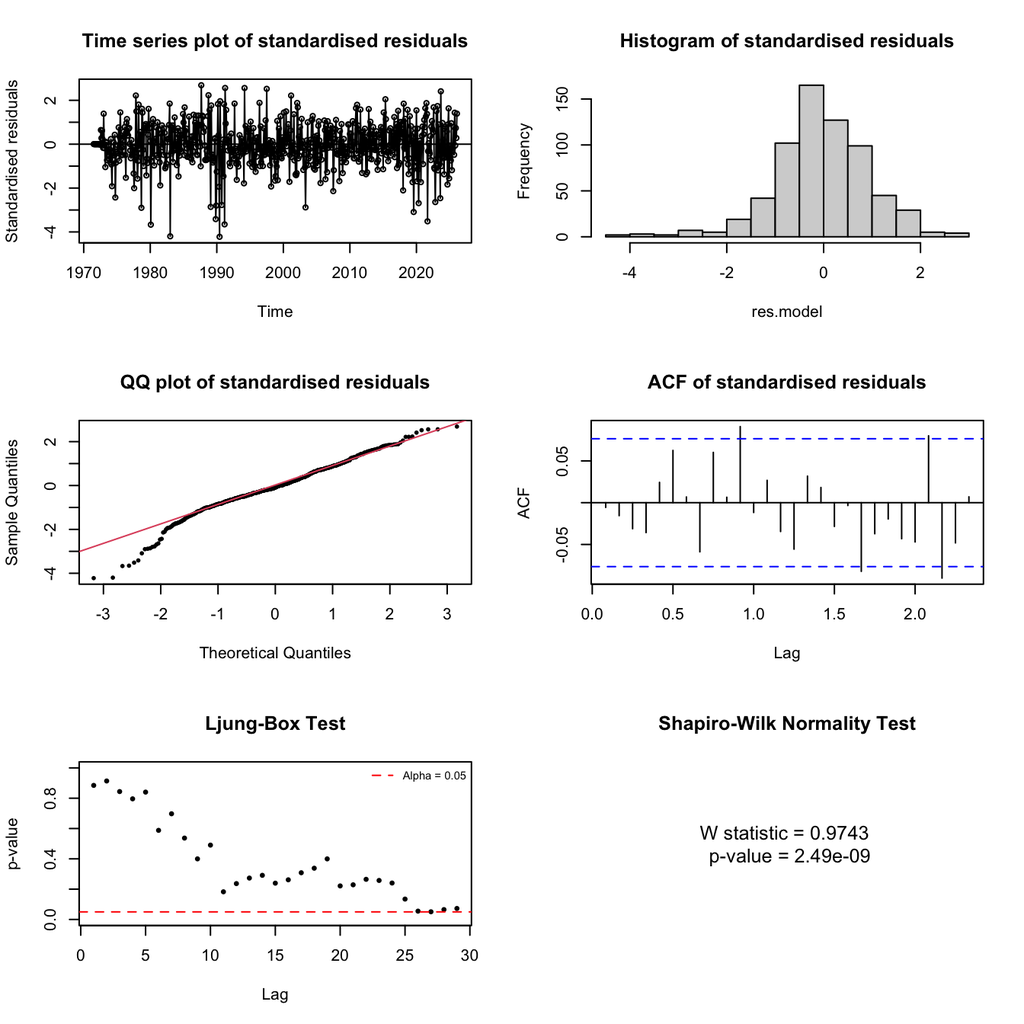

Figure 45: Residual diagnostics for the finalist model: M311 — SARIMA(3,1,1)(0,1,2)[12], ML.

```r
residuals_m311_ml <- residual.analysis(m311_ml, std = TRUE, model_class = "ARIMA")
```

# 8 Overfitting Check

Based on the combined evidence of AIC, BIC, coefficient significance, and residual diagnostics, **SARIMA**$(3,1,1)(0,1,2)_{12}$ (M311) is selected as the preferred finalist.

To confirm this choice, overfitting is assessed by fitting a model with **one additional AR or MA parameter beyond the preferred finalist** and evaluating whether the extra complexity adds genuine value. The evaluation proceeds sequentially:

- the overfitted model is first examined on coefficient significance and residual diagnostics. *If the additional term is statistically significant and the residual diagnostics improve upon the selected model*,
- the comparison is escalated to AIC/BIC ranking and in-sample accuracy metrics to determine whether the more complex model warrants selection. If, however, the additional term is insignificant or the residual diagnostics show no meaningful improvement, the overfitted model is immediately rejected and the more parsimonious finalist is confirmed without requiring further comparison on information criteria.

The two overfitting directions for the selected model SARIMA$(3,1,1)(0,1,2)_{12}$ are **p+1**, which would produce SARIMA$(4,1,1)(0,1,2)_{12}$, and **q+1**, which corresponds to SARIMA$(3,1,2)(0,1,2)_{12}$.

Since M312 was already estimated in the candidate set, its overfitting evidence is drawn directly from the coefficient tables, information criteria, and residual diagnostics already presented. No additional model fitting is required. However, SARIMA$(4,1,1)(0,1,2)_{12}$ was not estimated as a candidate yet.

## 8.1 Overfit by q+1 — M312: SARIMA$(3,1,2)(0,1,2)_{12}$

M312 was already estimated. Adding a second MA term to the selected M311 causes a complete collapse of the entire non-seasonal structure under both CSS and ML estimation. All five non-seasonal parameters, ar1, ar2, ar3, ma1, and ma2, are entirely insignificant across both methods.

The model is effectively reduced to a pure seasonal structure driven solely by sma1, with no non-seasonal dynamics whatsoever, a severe regression from M311’s well-identified AR(3) and MA(1) framework. AIC worsens from 1855.107 to 1865.638 (+10.531 units) and BIC worsens from 1886.370 to 1901.367 (+14.997 units). Residual diagnostics show no improvement over M311. Adding further complexity beyond M311 adds no explanatory value and actively degrades model quality.

With the q+1 path definitively ruled out due to structural collapse, the final component of the **overfitting verification requires testing the p+1 direction**. Accordingly, the SARIMA$(4,1,1)(0,1,2)_{12}$ model will be estimated next. Its resulting coefficient significance and residual diagnostics will be analyzed to confirm whether expanding the autoregressive structure yields any genuine predictive power.

## 8.2 Overfit by p+1 — M411: SARIMA$(4,1,1)(0,1,2)_{12}$

```r
m411_css <- Arima(WoolTS, order = c(4,1,1),
                  seasonal = list(order = c(0,1,2), period = 12),
                  method = "CSS", lambda = lambda_opt)
m411_ml  <- Arima(WoolTS, order = c(4,1,1),
                  seasonal = list(order = c(0,1,2), period = 12),
                  method = "ML", lambda = lambda_opt)
```

To verify the structural integrity of our baseline model, a formal overfitting test was conducted by expanding the non-seasonal parameter space. The resulting estimates demonstrate that the expanded structure cannot be supported: under CSS, all five non-seasonal parameters — ar1 (0.0244, p=0.938), ar2 (−0.1148, p=0.323), ar3 (0.0000, p=0.9996), ar4 (−0.0731, p=0.131), and ma1 (−0.3784, p=0.226) — are entirely insignificant, with ar3 returning a near-zero estimate signalling complete redundancy.

```r
make_coef_table(m411_css, "Coefficients: M411 — SARIMA(4,1,1)(0,1,2)[12], CSS")
```

Table 41: Coefficients: Overfitting p+1 (M411) — SARIMA(4,1,1)(0,1,2)[12], CSS

Coefficients: M411 — SARIMA(4,1,1)(0,1,2)[12], CSS

| Coefficient | Estimate | Std.Error | z.value | p.value | Sig |
| --- | --- | --- | --- | --- | --- |
| ar1 | 0.0244 | 0.3123 | 0.0782 | 0.9377 |  |
| ar2 | -0.1148 | 0.1162 | -0.9883 | 0.3230 |  |
| ar3 | 0.0000 | 0.0832 | 0.0005 | 0.9996 |  |
| ar4 | -0.0731 | 0.0483 | -1.5122 | 0.1305 |  |
| ma1 | -0.3784 | 0.3122 | -1.2120 | 0.2255 |  |
| sma1 | -0.7774 | 0.0421 | -18.4522 | 0.0000 | *** |
| sma2 | -0.0158 | 0.0421 | -0.3750 | 0.7077 |  |

To determine whether this structural failure is merely an artifact of the CSS optimization, the model was re-estimated using Maximum Likelihood. The ML estimation confirms this collapse without recovery: ar1 (0.0733, p=0.844), ar2 (−0.0989, p=0.476), ar3 (0.0109, p=0.912), ar4 (−0.0706, p=0.196), and ma1 (−0.4331, p=0.244) all remain entirely insignificant. Across both methods, only sma1 retains significance (CSS: −0.7774, p<0.001; ML: −0.7787, p<0.001), reducing the model to an effectively pure seasonal structure with no meaningful non-seasonal dynamics.

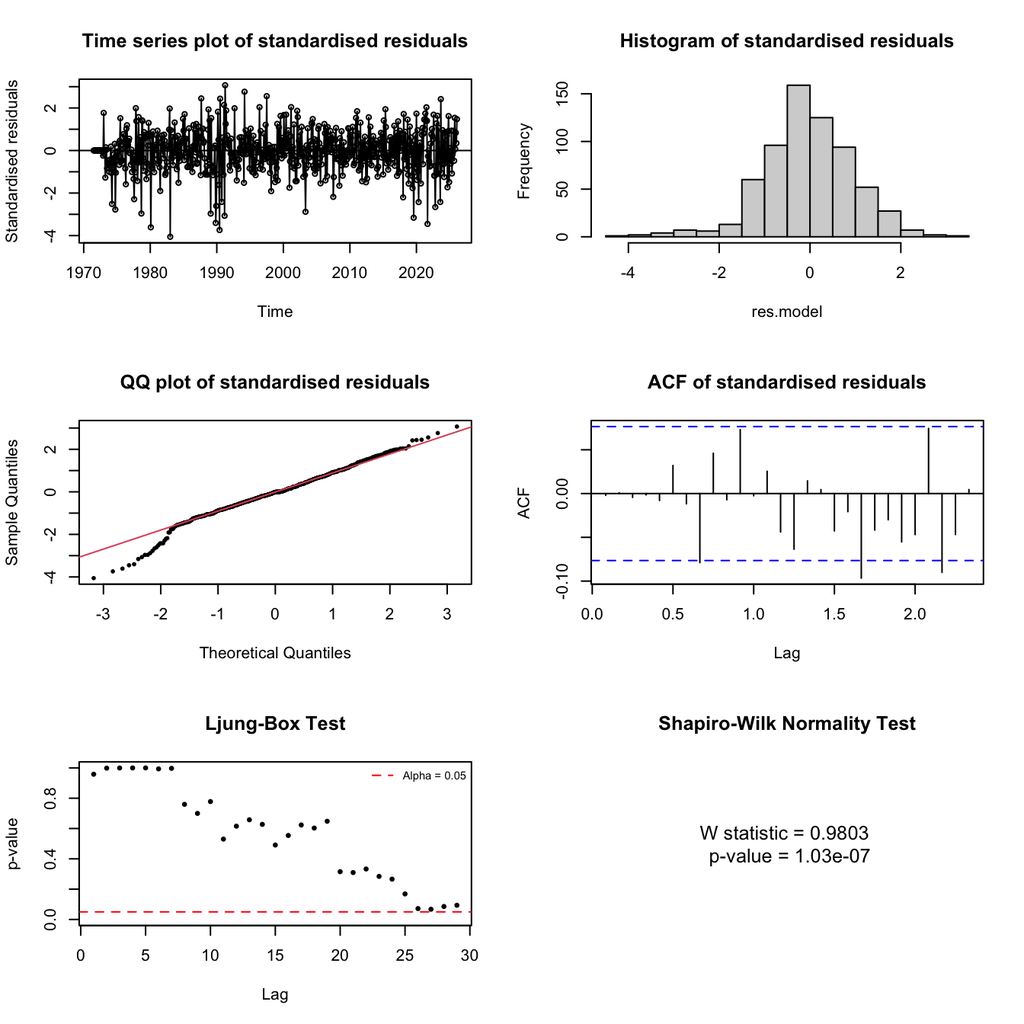

Figure 46: Residual diagnostics: M411 — SARIMA(4,1,1)(0,1,2)[12], CSS

```r
residuals_m411_css <- residual.analysis(m411_css, std = TRUE, model_class = "ARIMA")
```

```r
make_coef_table(m411_ml, "Coefficients: M411 — SARIMA(4,1,1)(0,1,2)[12], ML")
```

Table 42: Coefficients: Overfitting p+1 (M411) — SARIMA(4,1,1)(0,1,2)[12], ML

Coefficients: M411 — SARIMA(4,1,1)(0,1,2)[12], ML

| Coefficient | Estimate | Std.Error | z.value | p.value | Sig |
| --- | --- | --- | --- | --- | --- |
| ar1 | 0.0733 | 0.3710 | 0.1975 | 0.8435 |  |
| ar2 | -0.0989 | 0.1385 | -0.7135 | 0.4755 |  |
| ar3 | 0.0109 | 0.0982 | 0.1107 | 0.9119 |  |
| ar4 | -0.0706 | 0.0546 | -1.2940 | 0.1957 |  |
| ma1 | -0.4331 | 0.3720 | -1.1642 | 0.2444 |  |
| sma1 | -0.7787 | 0.0424 | -18.3790 | 0.0000 | *** |
| sma2 | -0.0105 | 0.0422 | -0.2483 | 0.8039 |  |

Adding a fourth AR term to the selected M311 produces a complete collapse of the non-seasonal structure under both CSS and ML estimation. This is a stark contrast to M311, where ar1, ar2, ar3, and ma1 all achieve significance under both ML and CSS-ML. The complete agreement between CSS and ML on total non-seasonal insignificance directly confirms that the AR(3) order in M311 is the correct and sufficient autoregressive specification. Extending to AR(4) adds no signal, destroys the identification achieved by M311, and introduces unnecessary complexity. The additional AR term cannot be accepted.

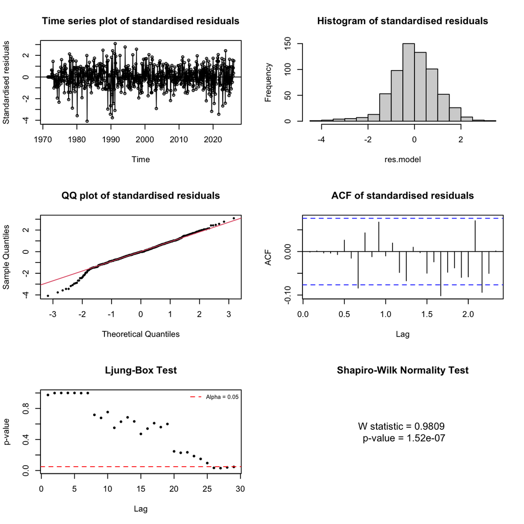

Figure 47: Residual diagnostics: M411 — SARIMA(4,1,1)(0,1,2)[12], ML

```r
residuals_m411_ml <- residual.analysis(m411_ml, std = TRUE, model_class = "ARIMA")
```

Under both CSS and ML, all five non-seasonal parameters (ar1, ar2, ar3, ar4, ma1) are entirely insignificant. Only sma1 retains significance, reducing the model to a pure seasonal structure. The p+1 direction adds no signal and destroys the identification achieved by M311.

## 8.3 Overfitting Decision

Both overfitting directions fail conclusively. The q+1 extension (M312) produces complete non-seasonal coefficient collapse with AIC worsening by 10.531 units and BIC by 14.997 units. The p+1 extension (M411) produces an identical collapse under both CSS and ML, with all five non-seasonal parameters insignificant across both estimation methods. Neither direction of extension adds any value beyond M311. **SARIMA**$(3,1,1)(0,1,2)_{12}$ is confirmed as the final selected model.

Having confirmed the final model, we now generate 30-month-ahead forecasts to illustrate its practical application.

# 9 Forecasting

With **SARIMA**$(3,1,1)(0,1,2)_{12}$ confirmed as the final selected model, we proceed to generate out-of-sample forecasts. The model was estimated on the full available series from July 1971 to February 2026. Forecasts are produced on the back-transformed AUD scale with 80% and 95% prediction intervals to characterise forecast uncertainty across the projection horizon.

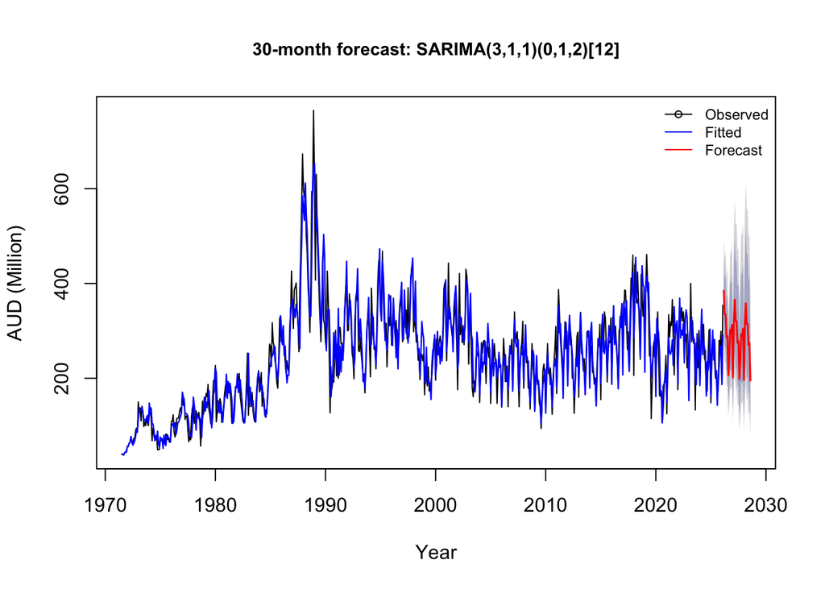

Figure 48: 30-month ahead forecast: SARIMA(3,1,1)(0,1,2)[12].

```r
mPREF       <- m311_ml
mPREF_label <- "SARIMA(3,1,1)(0,1,2)[12]"

frc_pref <- forecast::forecast(mPREF, h = 30)
plot(frc_pref,
     main = paste0("30-month forecast: ", mPREF_label),
     xlab = "Year", ylab = "AUD (Million)", cex.main = 0.9,
     fcol = "red", flwd = 1.5)
lines(fitted(mPREF), col = "blue", lwd = 1.2)
legend("topright", lty = 1, pch = c(1, NA, NA),
       col = c("black", "blue", "red"),
       legend = c("Observed", "Fitted", "Forecast"),
       cex = 0.75, bty = "n")
```

```r
frc_pref_df       <- as.data.frame(frc_pref)
frc_pref_df       <- round(frc_pref_df, 2)
frc_pref_df$Month <- rownames(frc_pref_df)
frc_pref_df       <- frc_pref_df[, c("Month", "Point Forecast",
                                      "Lo 80", "Hi 80", "Lo 95", "Hi 95")]

knitr::kable(frc_pref_df, align = "lrrrrr", row.names = FALSE, booktabs = TRUE)
```

Table 43: 30-month ahead forecasts with 80% and 95% prediction intervals: SARIMA$(3,1,1)(0,1,2)_{12}$.

| Month | Point Forecast | Lo 80 | Hi 80 | Lo 95 | Hi 95 |
| --- | --- | --- | --- | --- | --- |
| Mar 2026 | 385.05 | 323.03 | 454.44 | 293.06 | 494.31 |
| Apr 2026 | 335.14 | 269.40 | 410.67 | 238.34 | 454.84 |
| May 2026 | 334.81 | 263.96 | 417.21 | 230.82 | 465.77 |
| Jun 2026 | 286.30 | 217.65 | 367.89 | 186.18 | 416.69 |
| Jul 2026 | 288.62 | 215.72 | 376.16 | 182.60 | 428.87 |
| Aug 2026 | 206.47 | 146.33 | 281.00 | 119.80 | 326.79 |
| Sep 2026 | 243.94 | 174.11 | 330.12 | 143.19 | 382.92 |
| Oct 2026 | 302.10 | 218.82 | 403.99 | 181.65 | 466.07 |
| Nov 2026 | 296.54 | 212.46 | 400.07 | 175.15 | 463.42 |
| Dec 2026 | 312.74 | 223.81 | 422.30 | 184.38 | 489.37 |
| Jan 2027 | 201.65 | 135.20 | 286.69 | 106.78 | 340.00 |
| Feb 2027 | 317.68 | 225.05 | 432.49 | 184.21 | 503.03 |
| Mar 2027 | 365.58 | 259.40 | 497.05 | 212.55 | 577.78 |
| Apr 2027 | 321.09 | 221.89 | 445.84 | 178.75 | 523.19 |
| May 2027 | 319.82 | 219.16 | 447.01 | 175.60 | 526.12 |
| Jun 2027 | 274.51 | 182.62 | 392.64 | 143.50 | 466.89 |
| Jul 2027 | 278.18 | 184.14 | 399.43 | 144.22 | 475.77 |
| Aug 2027 | 198.21 | 123.37 | 298.12 | 92.71 | 362.36 |
| Sep 2027 | 236.09 | 150.49 | 348.85 | 114.92 | 420.77 |
| Oct 2027 | 292.66 | 192.10 | 422.93 | 149.62 | 505.19 |
| Nov 2027 | 288.39 | 188.07 | 418.84 | 145.85 | 501.40 |
| Dec 2027 | 304.57 | 199.56 | 440.76 | 155.24 | 526.81 |
| Jan 2028 | 196.01 | 118.73 | 300.76 | 87.56 | 368.71 |
| Feb 2028 | 309.70 | 202.14 | 449.49 | 156.85 | 537.94 |
| Mar 2028 | 358.02 | 236.55 | 514.80 | 185.05 | 613.57 |
| Apr 2028 | 314.90 | 202.65 | 461.96 | 155.76 | 555.46 |
| May 2028 | 314.15 | 201.06 | 462.80 | 153.96 | 557.48 |
| Jun 2028 | 269.91 | 167.44 | 406.96 | 125.54 | 495.17 |
| Jul 2028 | 274.01 | 169.62 | 413.82 | 126.98 | 503.87 |
| Aug 2028 | 195.21 | 112.75 | 309.98 | 80.40 | 385.56 |

The 30-month ahead forecast from **SARIMA**$(3,1,1)(0,1,2)_{12}$ is presented in Figure 48 and Table 43. Several features of the forecast are consistent with the historical behaviour documented in Section 2 and visible in Figure 1. The seasonal pattern is preserved throughout the forecast horizon. The forecast reveals a dual-trough, dual-peak within-year cycle consistent with the seasonal regularities identified in Figure 1.

Peaks occur in March (385.05, 365.58, and 358.02 AUD million across the three forecast years) and secondary peaks in December (312.74, 304.57 AUD million), reflecting the end-of-clip-season export surges historically associated with the December–March period.

Troughs occur in August (206.47, 198.21, and 195.21 AUD million) and January (201.65, 196.01 AUD million), consistent with the mid-year and post-New-Year trade lulls observed in Figure 1. Notably, point forecasts show a modest downward drift across the three forecast years, with the March peak declining from 385.05 in 2026 to 358.02 in 2028 and August troughs falling from 206.47 to 195.21, suggesting a gradual moderation in trade values over the projection horizon.

Prediction intervals widen progressively with the forecast horizon (Figure 48 and Table 43). The 95% interval for August 2026 is [119.80, 326.79] (a range of 207 AUD million), while by August 2028 it widens to [80.40, 385.56] (a range of 305 AUD million). This widening reflects the accumulation of uncertainty over multi-step projections and is an honest representation of the inherent volatility of this commodity series rather than a model deficiency.

# 10 Conclusion

This study applied a SARIMA modelling framework to 55 years of monthly Australian wool and sheepskins trade data spanning July 1971 to February 2026, with the objective of identifying a robust, parsimonious model capable of capturing both the seasonal dynamics and short-run dependencies of this commodity series.

The analysis proceeded through stages. A Box-Cox transformation with λ = 0.34was applied to stabilise the non-constant variance characteristic of the series. A sequential residual approach identified the seasonal structure as $(0,1,2)_{12}$ , one seasonal difference to remove the seasonal unit root and a two-term seasonal MA to absorb residual seasonal autocorrelation. And then, a non-seasonal difference $(d=1)$ was adopted conservatively given contradictory stationarity test results.

Eleven candidate SARIMA models were identified through ACF/PACF, EACF, and BIC subset selection. And these models are evaluated across three independent filters, parameter estimation stability and residual diagnostics, information criteria (AIC and BIC), and in-sample accuracy metrics.

**SARIMA**$(3,1,1)(0,1,2)_{12}$ emerged as the final selected model, confirmed by the overfitting check.

The 30-month ahead forecast projects a characteristic seasonal oscillation: trade values decline from early 2026 toward a mid-year trough in the June–August window, before recovering through the second half of the year with a peak approaching December. This pattern repeats coherently across the forecast horizon, consistent with the historical seasonal cycle driven by Australian wool clip schedules documented in Section 2. Prediction intervals widen progressively with the horizon, appropriately reflecting the compounding uncertainty inherent in a volatile commodity series.

# 11 Implications

These findings carry practical implications for the three stakeholder groups identified at the outset.

For **wool producers**, the forecast’s mid-year trough and year-end recovery provide a 6–12 month visibility window that aligns directly with biological shearing timelines, allowing producers to calibrate stocking levels and hedging decisions against an evidence-based price trajectory rather than ad hoc expectations.

For **policymakers**, the forecast intervals quantify the range of plausible trade outcomes and can be used to stress-test trade balance projections, identify concentration risk in the agricultural export portfolio, and time policy interventions to periods of anticipated market stress rather than reacting after the fact.

Without reliable forecasts, these decisions default to reactive management: overstocking into declining markets, understocking ahead of demand surges, and policy responses that lag structural shifts in trade values.

The SARIMA$(3,1,1)(0,1,2)_{12}$model developed here provides a statistically grounded, regularly updatable forecasting tool that directly addresses this gap, offering actionable foresight at the operational, commercial, and policy levels of the Australian wool export chain.

# 12 Limitations

Several limitations should be acknowledged. First, the sample period includes the 1991 structural break (collapse of the Reserve Price Scheme), which may distort parameter estimates. Second, the Box-Cox transformation’s confidence interval had an indeterminate upper bound. Third, the forecast assumes that historical patterns continue unchanged and cannot anticipate unprecedented future shocks.

# 13 Acknowledgement

We would like to express our sincere gratitude to Dr. Haydar Demirhan and Dr. Zhendong Huang for their valuable guidance throughout this project.

# 14 What Next

With the primary analysis of the full series complete, the essential next step is to address the structural change point identified in the data. In time-series modeling, a major structural break signifies that the underlying forces driving the data have fundamentally shifted. Because older patterns can distort current forecasts, standard econometric practice requires isolating the data after this shift and re-running the entire analytical pipeline.

```r
# Load data and build post-break sub-series
apx_Trade <- read.csv("International_Trade_in_Goods.csv", header = TRUE)

apx_WoolTS_full <- ts(
  apx_Trade$Wool...sheepskins..in..M.,
  start     = c(1971, 7),
  end       = c(2026, 2),
  frequency = 12
)

# Post-structural break: January 1990 onward
apx_WoolTS <- window(apx_WoolTS_full, start = c(1990, 1))
```

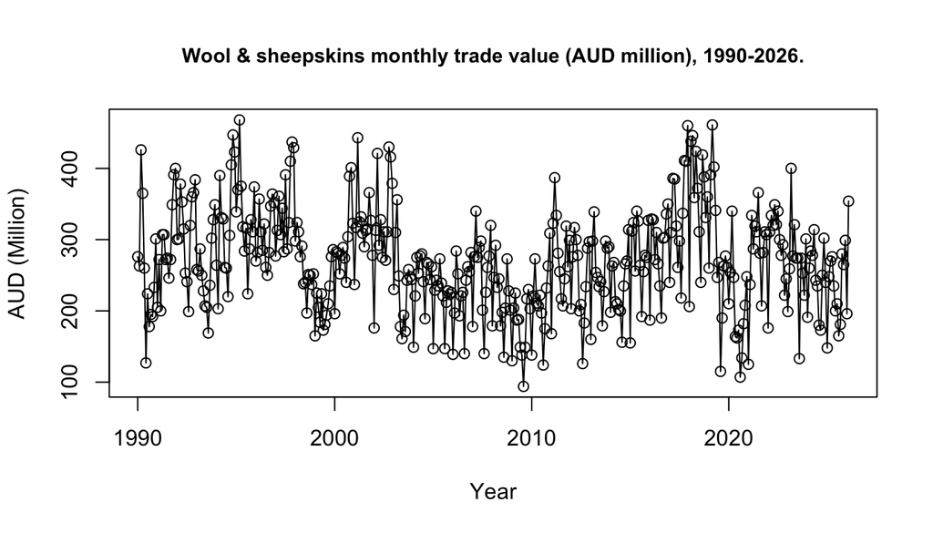

```r
plot_ts(
  apx_WoolTS,
  main = "Wool & sheepskins monthly trade value (AUD million), 1990-2026.",
  ylab = "AUD (Million)"
)
```

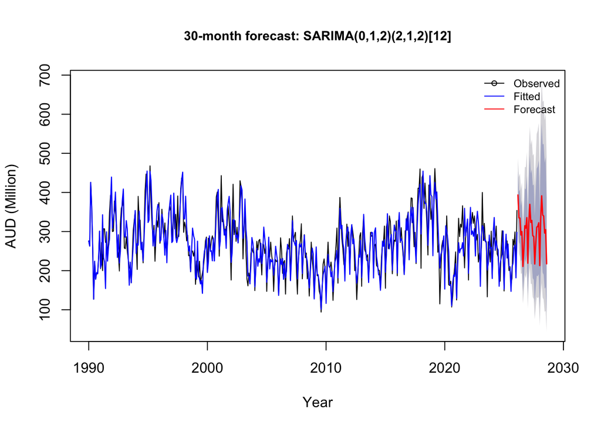

Figure 50: 30-month ahead forecast: SARIMA(0,1,2)(2,1,2)[12].

```r
## Model Fitting
apx_m012_ml    <- Arima(apx_WoolTS, order = c(0,1,2),
                        seasonal = list(order = c(2,1,2), period = 12),
                        method = "ML",     lambda = 0.58)

## Foracsting
mPREF       <- apx_m012_ml
mPREF_label <- "SARIMA(0,1,2)(2,1,2)[12]"

frc_pref <- forecast::forecast(mPREF, h = 30)
plot(frc_pref,
     main = paste0("30-month forecast: ", mPREF_label),
     xlab = "Year", ylab = "AUD (Million)", cex.main = 0.9,
     fcol = "red", flwd = 1.5)
lines(fitted(mPREF), col = "blue", lwd = 1.2)
legend("topright", lty = 1, pch = c(1, NA, NA),
       col = c("black", "blue", "red"),
       legend = c("Observed", "Fitted", "Forecast"),
       cex = 0.75, bty = "n")
```

# 15 References

ABARES (Australian Bureau of Agricultural and Resource Economics and Sciences) 2022, *Natural fibres: September 2022*, ABARES, Australian Government, viewed 29 April 2026, https://www.agriculture.gov.au/abares/research-topics/agricultural-outlook/natural-fibres-sept-2022.

ABS (Australian Bureau of Statistics) 2024, *International trade in goods, Table 3: Goods credits, original, current prices*, cat. no. 5368.0, ABS, viewed 29 April 2026, https://www.abs.gov.au/statistics/economy/international-trade/international-trade-goods/latest-release#data-downloads.

Chan, KS & Ripley, B 2022, ‘TSA: time series analysis’, R package version 1.3.1, viewed 29 April 2026, https://CRAN.R-project.org/package=TSA.

Cryer, JD & Chan, KS 2008, *Time series analysis: with applications in R*, 2nd edn, Springer, New York.

Demirhan, H 2026, *MATH1318 Time Series Analysis: Lecture Online Modules 1–9*, course material for MATH1318 Time Series Analysis, RMIT University, Melbourne.

Hyndman, RJ & Athanasopoulos, G 2021, *Forecasting: principles and practice*, 3rd edn, OTexts, Melbourne, viewed 29 April 2026, https://otexts.com/fpp3/.

Hyndman, RJ, Athanasopoulos, G, Bergmeir, C, et al. 2023, ‘forecast: forecasting functions for time series and linear models’, R package version 8.21.1, viewed 29 April 2026, https://CRAN.R-project.org/package=forecast.

National Museum of Australia n.d., ‘Merino sheep introduced’, National Museum of Australia, viewed 29 April 2026, https://www.nma.gov.au/defining-moments/resources/merino-sheep-introduced.

Robinson, D, Hayes, A & Couch, S 2023, ‘broom: convert statistical objects into tidy tibbles’, R package version 1.0.5, viewed 29 April 2026, https://CRAN.R-project.org/package=broom.

The Merino Polo 2020, ‘The decline of the Australian Merino industry since 1990 and why it’s time for a revival’, The Merino Polo, viewed 29 April 2026, https://themerinopolo.com.au/blogs/news/the-decline-of-the-australian-merino-industry-since-1990-and-why-it-s-time-for-a-revival.

Tran, LVT & Pham, TT 2024, ‘Seasonal ACF/PACF, sort.score, and residual.analysis helper functions’, unpublished R functions, MATH1318, RMIT University, Melbourne.

Trapletti, A & Hornik, K 2024, ‘tseries: time series analysis and computational finance’, R package version 0.10-56, viewed 29 April 2026, https://CRAN.R-project.org/package=tseries.

Wickham, H, François, R, Henry, L, Müller, K & Vaughan, D 2023, ‘dplyr: a grammar of data manipulation’, R package version 1.1.4, viewed 29 April 2026, https://CRAN.R-project.org/package=dplyr.

Xie, Y 2024, ‘knitr: a general-purpose package for dynamic report generation in R’, R package version 1.48, viewed 29 April 2026, https://CRAN.R-project.org/package=knitr.

Zeileis, A & Hothorn, T 2002, ‘Diagnostic checking in regression relationships’, *R News*, vol. 2, no. 3, pp. 7–10, viewed 29 April 2026, https://CRAN.R-project.org/doc/Rnews/.

Zhu, H 2024, ‘kableExtra: construct complex table with kable and pipe syntax’, R package version 1.4.0, viewed 29 April 2026, https://CRAN.R-project.org/package=kableExtra.